# Estratificación Conteo Rápido 2021

Chihuahua, Nayarit, Zacatecas, Colima

M. Anzarut, F. González, I. Meza, T. Ortiz

2/22/2021

## Métodos

- Presentamos resultados para **200 muestras** distintas para cada estado, estratificación, y fracción de muestreo utilizada.
- Para la estimación utilizamos el **estimador de razón combinado**, con error estándar estimado según remuestreo no paramétrico.
- Para censurar muestras por tiempo de llegada utilizamos **modelos de supervivencia** ajustados para datos de hora de llegada de información de 2018. [Reporte tiempos de llegada](https://sim-llegadas-3e5e7b.netlify.app/)
- Para muestras censuradas, colapsamos estratos vacíos dentro de distritos federales.

## Estratificaciones exploradas

Para las simulaciones usamos como marco la tabla de cómputos distritales de 2018 para los estados de interés

| Estado | # Distritos Fed | # Casillas |
| --- | --- | --- |
| CHIH | 9 | 5286 |
| COL | 2 | 950 |
| NAY | 3 | 1668 |
| ZAC | 4 | 2508 |

Utilizaremos cuatro variables para construir estratificaciones:

- **Distrito federal** (todos dentro de cada estado)
- Índice de **marginacion** a nivel seccion (INEGI 2010) (1 o 2 subgrupos)
- Tamaño de **lista nominal** (1 o 2 subgrupos)
- Índice de **votos en 2015** a nivel sección, una componente principal (1 o 2 subgrupos)

En cada estado, cruzamos el número de distritos federales con una de las siguientes configuraciones:

| estratificacion_num | indice_marginacion | lista_nominal | indice_votos |
| --- | --- | --- | --- |
| 1 | 1 | 1 | 1 |
| 2 | 1 | 1 | 2 |
| 3 | 1 | 2 | 1 |
| 4 | 1 | 2 | 2 |
| 5 | 2 | 1 | 1 |
| 6 | 2 | 1 | 2 |
| 7 | 2 | 2 | 1 |
| 8 | 2 | 2 | 2 |

- En todos los casos, se **colapsaron estratos** del diseño (usando las variables de derecha a izquierda en la tabla de arriba) hasta conseguir un mínimo de 60 casillas por estrato. No se colapsaron distritos federales.
- En todos los casos, la asignación de muestra es **proporcional** al tamaño del estrato.

# Colima, Nayarit y Zacatecas

## Cobertura y precisión con muestra al 90%

En este primer escenario evaluamos las estratificaciones, bajo distintos tamaños de muestra, haciendo el *supuesto optimista* de que 90% de la muestra será recibida.

Las estratificaciones más finas presentan mejoras en precisión en relación con la estratificación que sólo utiliza distritos federales:

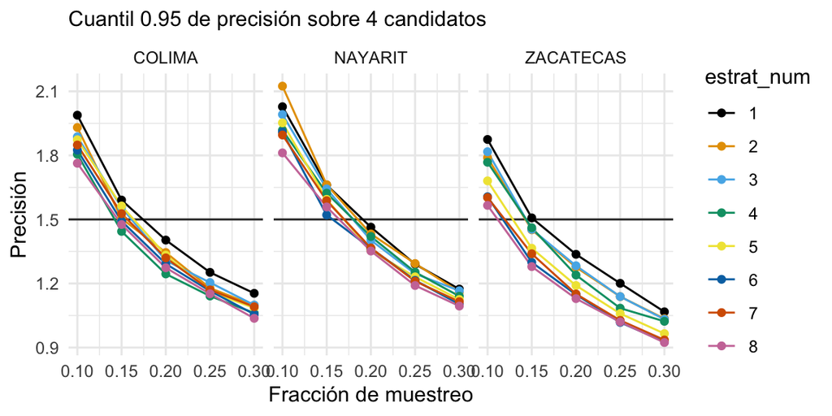

#### Conclusiones 1

- Bajo muestra casi completa (90%) es posible mejorar la precisión usando estratificaciones más finas que utilizan varios factores incluídos en el análisis.

Las coberturas son cercanas a las nominales de 95%:

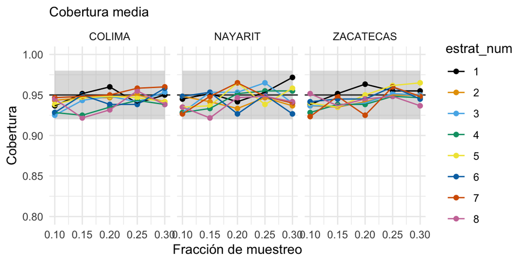

#### Conclusiones 2

- Las estratificaciones producen intervalos con cobertura real cercana nominal para un total de 90% de muestra observada.
- Para Zacatecas y Nayarit la estratificación 6 (distrito federal x 2 grupos de marginación x 2 grupos de votos 2015) tiene buena precisión, y es más simple que la estratificación 8.
- En Colima buenas posibilidades son la estratificación 6 y la 4 (distrito federal x 2 grupos de lista nominal x 2 grupos de votos 2015).
- En conclusión, escogemos la estratificacion 6 para estos tres estados.

## Cobertura y precisión con muestras censuradas

Ahora consideramos escenarios de mayor censura:

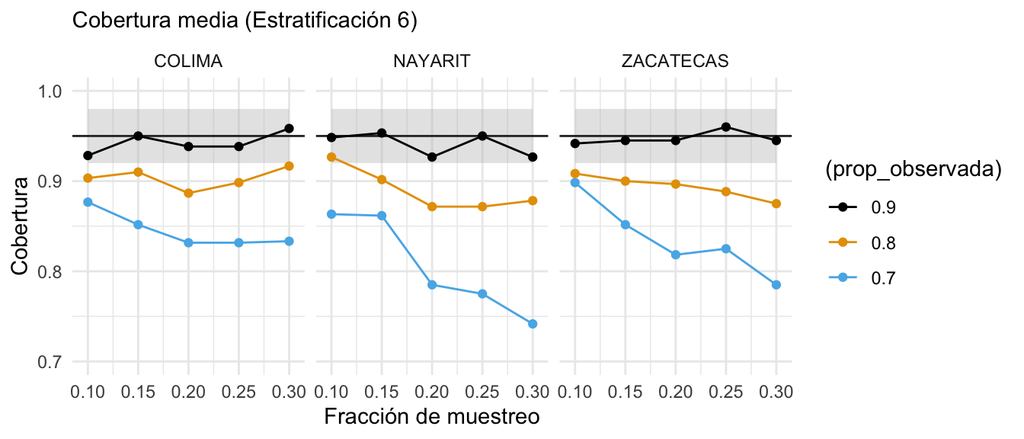

#### Conclusiones 3

- La cobertura se degrada considerablemente a lo largo de todos los estados, (para todas las estratificaciones de manera similar), conforme el porcentaje de datos censurados aumenta.
- Con 70% de muestra observada, la cobertura es baja en todos los estados, y otros modelos o correcciones son necesarias para construir intervalos que tengan cobertura real cercana a 95%

## Propuesta de diseño

| Estado | frac_m | n_muestra | prop_observada | precision_ajustada | num_estratos | n_obs |
| --- | --- | --- | --- | --- | --- | --- |
| COLIMA | 0.15 | 142 | 0.7 | 2.3 | 8 | 100 |
|  | 0.15 | 142 | 0.8 | 1.9 | 8 | 114 |
|  | 0.15 | 142 | 0.9 | 1.5 | 8 | 128 |
| NAYARIT | 0.15 | 250 | 0.7 | 2.5 | 12 | 175 |
|  | 0.15 | 250 | 0.8 | 1.9 | 12 | 200 |
|  | 0.15 | 250 | 0.9 | 1.5 | 12 | 225 |
| ZACATECAS | 0.10 | 251 | 0.7 | 2.5 | 16 | 176 |
|  | 0.10 | 251 | 0.8 | 2.0 | 16 | 201 |
|  | 0.10 | 251 | 0.9 | 1.6 | 16 | 226 |

Nota:  
Precisión ajustada considera expansión de intervalo para cumplir cobertura nominal de 95%

## Número de casillas por CAE

En la siguiente tabla mostramos el promedio de porcentaje de CAEs con 1,2,3 o 4 casillas.

| Estado | frac_muestreo | 1 | 2 | 3 | 4 |
| --- | --- | --- | --- | --- | --- |
| COL | 0.1 | 84.3 | 14.4 | 1.2 | 0.0 |
| COL | 0.15 | 75.7 | 21.4 | 2.8 | 0.2 |
| COL | 0.2 | 68.3 | 26.4 | 4.9 | 0.4 |
| NAY | 0.1 | 81.4 | 16.8 | 1.7 | 0.1 |
| NAY | 0.15 | 72.8 | 23.0 | 3.8 | 0.4 |
| NAY | 0.2 | 64.0 | 28.4 | 6.6 | 0.9 |
| ZAC | 0.1 | 85.2 | 13.8 | 1.0 | 0.0 |
| ZAC | 0.15 | 78.2 | 19.4 | 2.3 | 0.1 |
| ZAC | 0.2 | 70.6 | 25.1 | 4.0 | 0.3 |

# Chihuahua (preliminar)

## Cobertura y precisión con muestra al 90%

En Chihuahua observamos un patrón similar con muestra observada de 90% en cuanto a precisión:

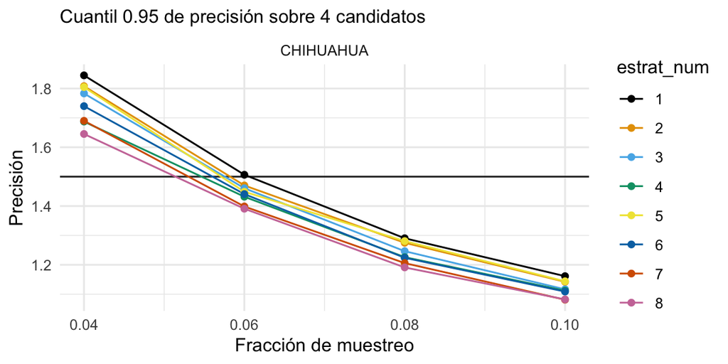

## Cobertura con muestras censuradas

Sin embargo, la cobertura decae fuertemente conforme muestra observada decrece, a una tasa muy mayor a la observada en Nayarit, Colima y Zacatecas:

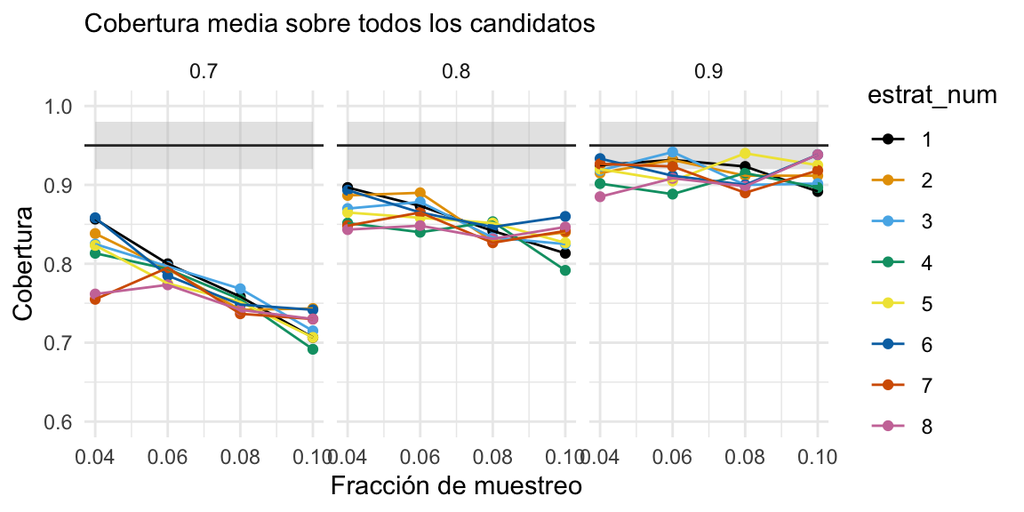

#### Conclusiones preliminares

- Incluso con 80% de muestra observada, la cobertura real está lejos de la nominal
- Con 90% de la muestra, las estratificación 3 (distrito federal x 2 grupos de lista nominal) puede ser razonable en sesgo para una fracción de muestreo menor a 0.10.

### Propuestas de diseño (preliminares)

| NOMBRE_ESTADO | estrat_num | frac_m | n | prop_observada | precision_ajustada | n_obs |
| --- | --- | --- | --- | --- | --- | --- |
| CHIHUAHUA | 1 | 0.06 | 317 | 0.7 | 2.36 | 222 |
|  |  | 0.06 | 317 | 0.8 | 1.88 | 254 |
|  |  | 0.06 | 317 | 0.9 | 1.51 | 285 |
|  |  | 0.08 | 423 | 0.7 | 2.06 | 296 |
|  |  | 0.08 | 423 | 0.8 | 1.64 | 338 |
|  |  | 0.08 | 423 | 0.9 | 1.29 | 381 |
|  | 3 | 0.06 | 317 | 0.7 | 2.32 | 222 |
|  |  | 0.06 | 317 | 0.8 | 1.85 | 254 |
|  |  | 0.06 | 317 | 0.9 | 1.46 | 285 |
|  |  | 0.08 | 423 | 0.7 | 2.01 | 296 |
|  |  | 0.08 | 423 | 0.8 | 1.61 | 338 |
|  |  | 0.08 | 423 | 0.9 | 1.25 | 381 |
|  | 6 | 0.06 | 317 | 0.7 | 2.33 | 222 |
|  |  | 0.06 | 317 | 0.8 | 1.84 | 254 |
|  |  | 0.06 | 317 | 0.9 | 1.44 | 285 |
|  |  | 0.08 | 423 | 0.7 | 1.96 | 296 |
|  |  | 0.08 | 423 | 0.8 | 1.59 | 338 |
|  |  | 0.08 | 423 | 0.9 | 1.22 | 381 |

Nota:  
Precisión ajustada considera expansión de intervalo para cumplir cobertura nominal de 95%

# Apéndice

## Número de casillas por estrato para CHIH, NAY, COL y ZAC

| Estado | estrato | n_casillas |
| --- | --- | --- |
| COL | 1.1.1.1 | 172 |
|  | 1.1.2.1 | 172 |
|  | 1.2.1.1 | 160 |
|  | 2.1.1.1 | 177 |
|  | 2.1.2.1 | 84 |
|  | 2.2.2.1 | 185 |
| NAY | 1.1.1.1 | 80 |
|  | 1.2.1.1 | 315 |
|  | 1.2.2.1 | 181 |
|  | 2.1.1.1 | 152 |
|  | 2.1.2.1 | 323 |
|  | 2.2.1.1 | 87 |
|  | 3.1.1.1 | 112 |
|  | 3.1.2.1 | 167 |
|  | 3.2.1.1 | 165 |
|  | 3.2.2.1 | 86 |
| ZAC | 1.1.1.1 | 128 |
|  | 1.1.2.1 | 150 |
|  | 1.2.1.1 | 179 |
|  | 1.2.2.1 | 120 |
|  | 2.1.1.1 | 211 |
|  | 2.1.2.1 | 160 |
|  | 2.2.1.1 | 378 |
|  | 3.1.1.1 | 70 |
|  | 3.1.2.1 | 273 |
|  | 3.2.1.1 | 192 |
|  | 3.2.2.1 | 92 |
|  | 4.1.1.1 | 143 |
|  | 4.1.2.1 | 213 |
|  | 4.2.2.1 | 199 |

| Estado | estrato | n_casillas |
| --- | --- | --- |
| CHIH | 1.1.1.1 | 146 |
|  | 1.1.2.1 | 188 |
|  | 1.2.1.1 | 94 |
|  | 1.2.2.1 | 122 |
|  | 2.1.1.1 | 165 |
|  | 2.2.1.1 | 167 |
|  | 2.2.2.1 | 245 |
|  | 3.1.1.1 | 150 |
|  | 3.2.2.1 | 368 |
|  | 4.1.1.1 | 144 |
|  | 4.1.2.1 | 133 |
|  | 4.2.1.1 | 153 |
|  | 4.2.2.1 | 182 |
|  | 5.1.1.1 | 109 |
|  | 5.1.2.1 | 266 |
|  | 5.2.1.1 | 78 |
|  | 5.2.2.1 | 150 |
|  | 6.1.1.1 | 570 |
|  | 6.2.1.1 | 73 |
|  | 7.1.1.1 | 200 |
|  | 7.2.1.1 | 227 |
|  | 7.2.2.1 | 227 |
|  | 8.1.1.1 | 480 |
|  | 8.2.1.1 | 119 |
|  | 9.1.1.1 | 166 |
|  | 9.2.1.1 | 63 |
|  | 9.2.2.1 | 301 |

## Porcentaje de muestra recibida por estado (presidencial 2018)

La gráfica de abajo muestra el porcentaje de muestra en la remesa de salida de 2018, para aquellos estados en los que no hubo elección de gobernador. La fracción de muestreo es similar en todos los estados.

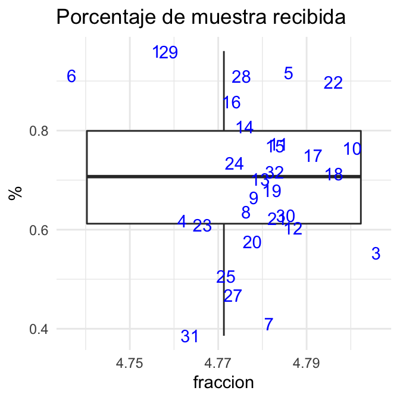

## Casillas asignadas y entregadas por CAE

Para este ejercicio se utilizó el marco muestral de la elección presidencial 2018, y a remesa de las 12:30.

De acuerdo al marco hubo 6,655 CAEs con una casilla, 521 CAEs con dos casillas y 30 CAEs con tres.

| n | caes | prop |
| --- | --- | --- |
| 1 | 6655 | 92.4 |
| 2 | 521 | 7.2 |
| 3 | 30 | 0.4 |

Cambiamos la unidad de observación a la casilla.

| n | casilla | prop |
| --- | --- | --- |
| 1 | 6655 | 85.5 |
| 2 | 1042 | 13.4 |
| 3 | 90 | 1.2 |

| n | planeadas | reportadas | faltantes | porcent |
| --- | --- | --- | --- | --- |
| 1 | 6655 | 5414 | 1241 | 81 |
| 2 | 1042 | 829 | 213 | 80 |
| 3 | 90 | 64 | 26 | 71 |

Notamos diferencias chicas entre 1 y 2 casillas asignadas.

Repetimos cortando a las 10:30 pm y obtenemos la siguiente tabla.

| casillas_plan | plan | reportadas | faltantes | porcent |
| --- | --- | --- | --- | --- |
| 1 | 6655 | 4563 | 2092 | 69 |
| 2 | 1042 | 682 | 360 | 65 |
| 3 | 90 | 53 | 37 | 59 |